# Animal Circulation and Gas Exchange

## Things to Know (#s)

- **#Molecule Trading**
- **#Circulatory Basics**
- **#Circulatory Mammal**
- **#Respiratory Structures**

## The Big Picture: Circulation and Gas Exchange

- **Direct exchange between every cell and the environment is not possible in all animals (*remember square-cube law*)**
  - structures for exchange & transport needed
- **Respiratory systems:**
- **Circulatory systems:**
- **Internal transport and gas exchange functionally related**

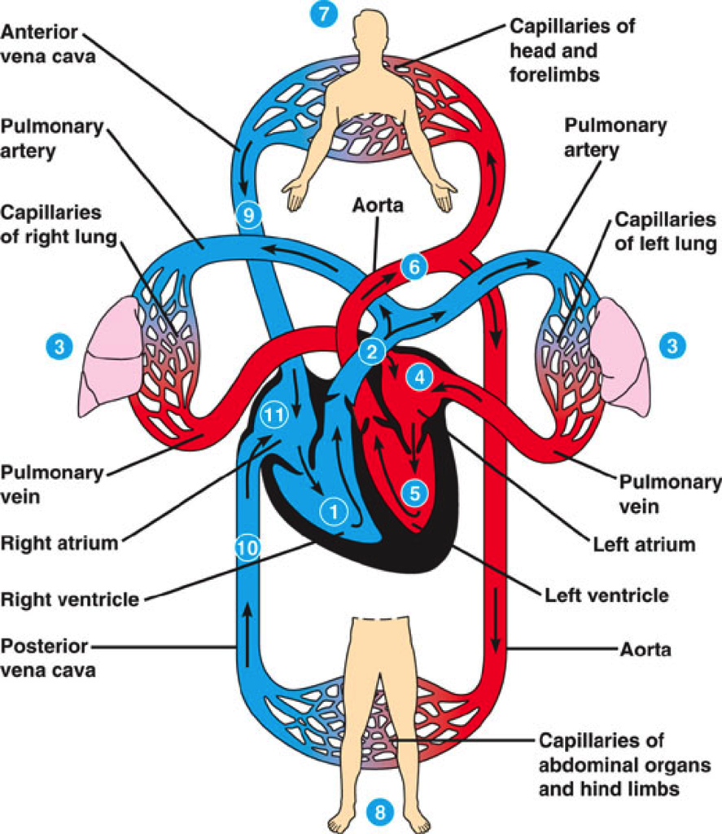

## Molecule trading

- **Small molecules can move between cells and their surroundings by *diffusion***
- **Diffusion is only efficient over small distances**
- **Molecule trading in animals must occur for every cell**
  - gain O<sub>2</sub> and nutrients
  - release CO<sub>2</sub> and waste products
- **Simple body plans:**
- **Complex body plans:**

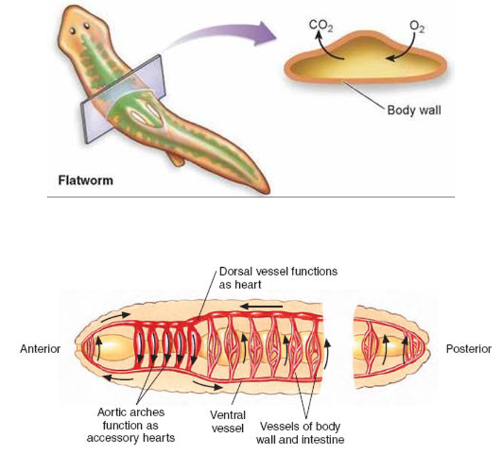

## Animals with gastrovascular cavities

- **Many animals have lots of cells in contact with environment**
  - hydras, jellyfish, flatworms
- **Central *gastrovascular cavity* functions to distribute substances**
  - opening at one end connects cavity to water
  - allows fluid to also bath inner tissues/cells
  - *diffusion distance with environment remains short*
- **Gastrovascular cavity can be highly branched**
  - extends into tentacles of cnidarians
  - covers high surface area within flatworm bodies

[figure not shown]

## Animals with circulatory systems (most bilateral animals)

- **Circulatory systems have 3 components**
- **Fluid transport, via vessels, connects cytoplasm of cells to the gas exchange organs**
- **Mammals → O<sub>2</sub> diffuses over just 2 cell layers in lungs to reach blood**
- **Molecule trading with circulatory fluid often works like a circuit**

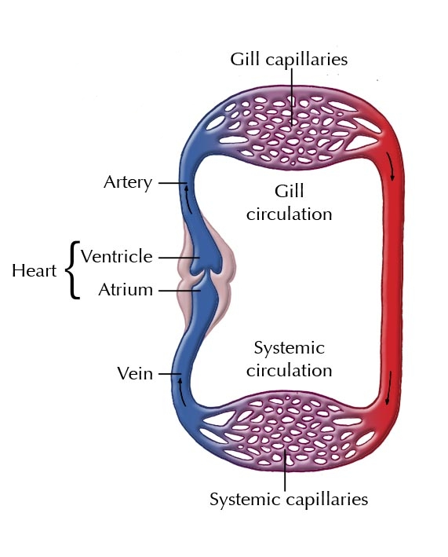

## Open and closed circulatory systems (hemolymph vs blood)

[figure not shown]

## Vertebrate Circulatory systems

- **Cardiovascular system: blood → heart → vessels**
  - length of vessels can be staggering
- **3 main types of vessels**
1. Arteries:
2. Veins:
3. Capillaries:
- **Hearts of vertebrates have 2+ muscular chambers**
  - *atria*:
  - *ventricles*:
- **Number of chambers related to form and function**

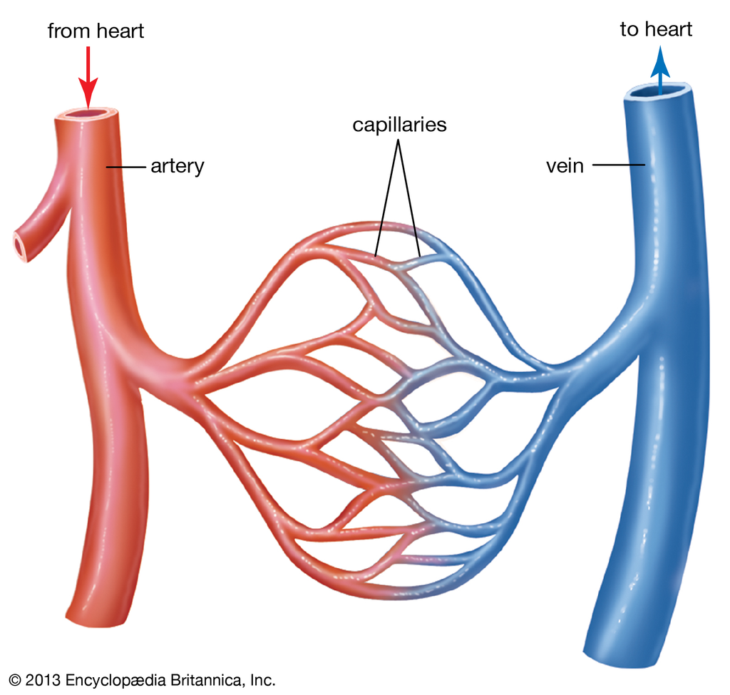

## Single vs Double circulation in vertebrates

[figure not shown]

## Evolutionary variation: 3 chambered heart

[figure not shown]

- **Amphibians and reptile hearts have only 1 ventricle**
  - still use double circulation
- **Do not always fill their lungs**
  - pass long periods without gas exchange when underwater
  - or use another tissue (skin)
- **Example: frogs use skin when underwater**
- **Example: crocodiles shunt blood from lungs when underwater**

## Mammalian Circulation (1st circuit)

- **The heart contracts and relaxes in a rhythmic cycle called the cardiac cycle**
- **Right ventricle pumps blood to the lungs via arteries**
- **Blood flows through capillaries into lungs and loads O<sub>2</sub> and unloads CO<sub>2</sub>**
- **O<sub>2</sub> rich blood returns from lungs via veins to the left atrium**

[figure not shown]

## Mammalian Circulation (2nd circuit)

- **Blood flows to left ventricle and is pumped to tissues via arteries into capillaries**
  - first branches supply the heart muscles
  - further branches lead to organs and limbs
- **O<sub>2</sub> diffuses from blood to tissues, and CO<sub>2</sub> diffuses from tissues to blood**
- **Capillaries rejoin conveying blood to veins**
  - O<sub>2</sub> poor blood from the head, neck, and forelimbs is emptied into right atrium

[figure not shown]

## Blood flow is reduced in capillaries

- **Physical laws govern movement of fluids through pipes**
  - affect blood flow and pressure
- **Blood flows from areas of higher pressure to low**
  - narrow diameter capillaries decrease pressure
- **Blood flow is slowest in the capillaries**
  - spread over large cross-sectional area
  - *necessary for efficient gas exchange*

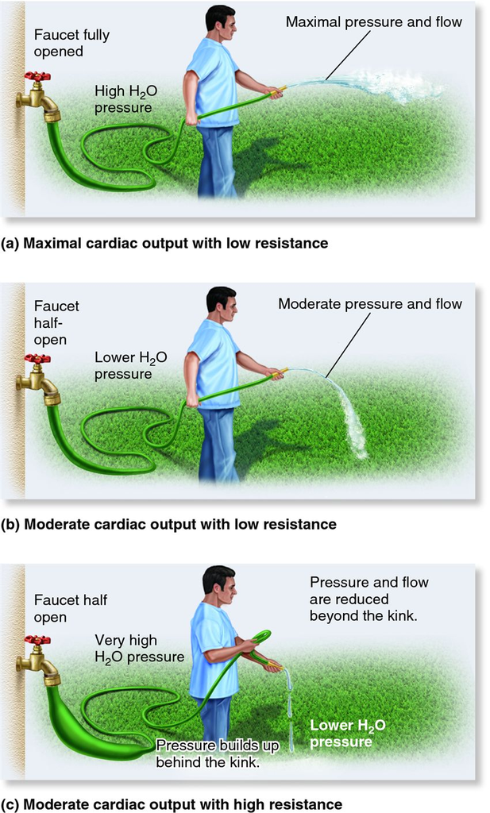

## Gas exchange occurs across respiratory surfaces

- **Gas exchange = uptake of O<sub>2</sub> and release of CO<sub>2</sub>**
  - O<sub>2</sub> is abundant in the air (21%)
  - fairly easily to ‘breath’
- **Water is more demanding for gas exchange**
  - dissolved O<sub>2</sub> is variable but always less than air
- **Efficient surfaces for gas exchange have evolved across animals that live in water and on land**
  - form is always going to include high surface area

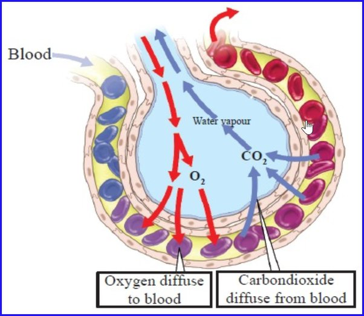

## Respiratory Surfaces

- **Differs across animal phylogeny**
  - sponges, cnidaria, flatworm → cells directly
  - earthworms, amphibians → skin
- **Other animals lack enough surface area**
  - to many inner cells to supply with O<sub>2</sub>
- **Different respiratory organs evolved:**
  - Gills → aquatic animals
  - Trachea → insects
  - Lungs → reptiles and mammals

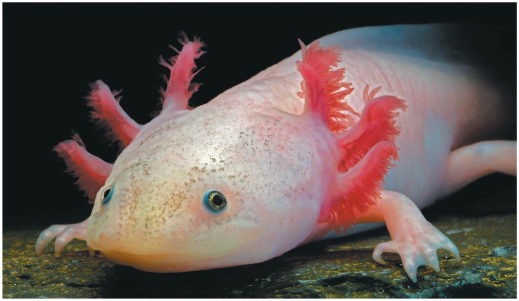

## Gills in fish

**Fish exchange gases by pulling oxygen-rich water through their mouths and pumping it over their gills. Within the gill filaments, capillary blood flows in the opposite direction to the water**

[figure not shown]

## Trachea in insects

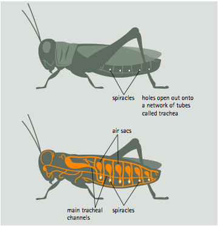

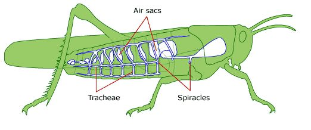

## Lungs in mammals, reptiles, and birds

**Elastic sacs with branching passages into which air is drawn, so that oxygen can pass into the blood and carbon dioxide be removed**

[figure not shown]

[figure not shown]

## Coordination of circulation and gas exchange

- **Animals need to exchange large amounts of O<sub>2</sub> and CO<sub>2</sub>**
  - to meet metabolic needs of all cells
- **During inhalation, fresh air fills in lungs**
  - molecule trading occurs via diffusion
- **Blood is then pumped through circuit**
  - O<sub>2</sub> carried in pigments (metal bound to protein)
  - CO<sub>2</sub> picked up from body cells and returned to sites of exchange with environment

[figure not shown]

[figure not shown]